# ppatil8_hw6

Prachi Vijay Patil

2023-12-06

# 9.6 Lab

# 9.6.1

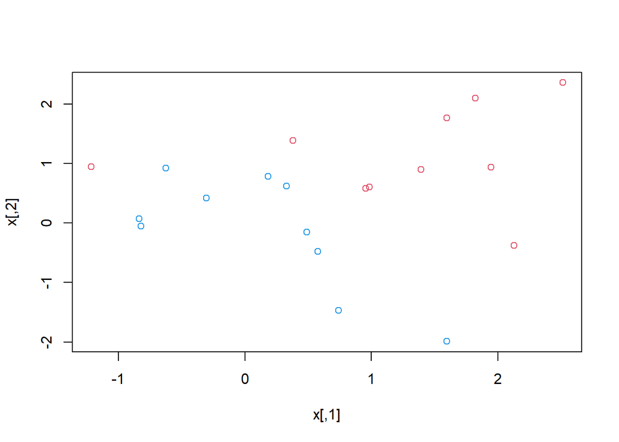

```r
set.seed(1)
x <- matrix(rnorm(20 * 2), ncol = 2)
y <- c(rep(-1, 10), rep(1, 10))
x[y == 1, ] <- x[y == 1, ] + 1
plot(x, col = (3 - y))
```

```r
dat <- data.frame(x = x, y = as.factor(y))
library(e1071)
```

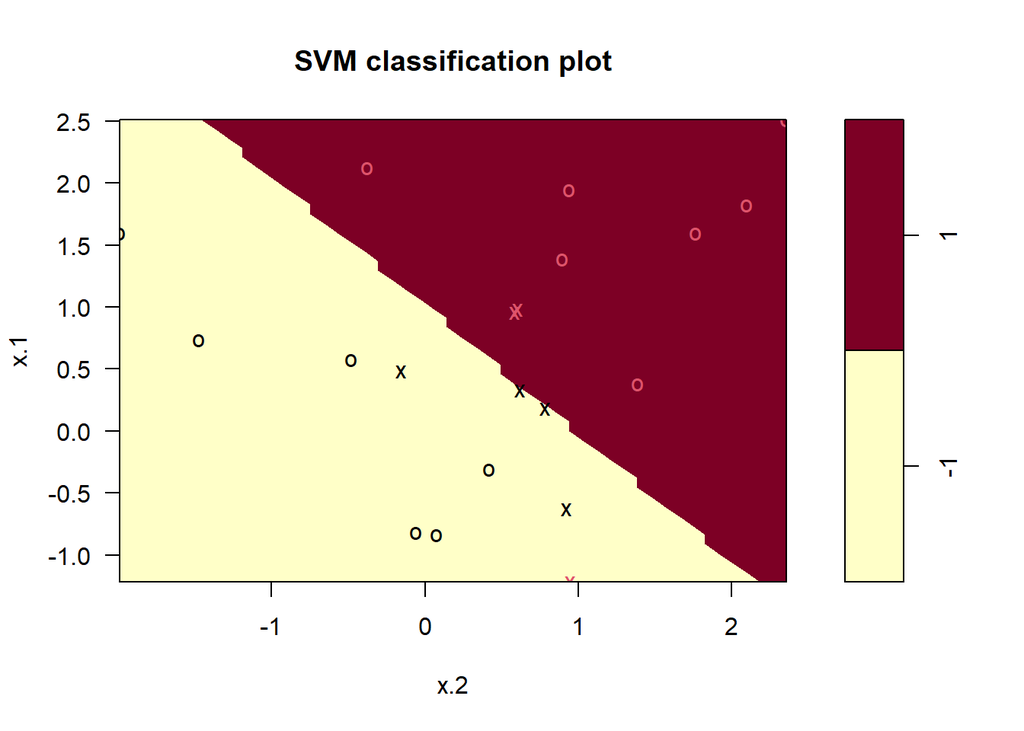

```r
svmfit <- svm(y ~ ., data = dat, kernel = "linear", cost = 10, scale = FALSE)
plot(svmfit, dat)
```

```r
svmfit$index
```

```
## [1]  1  2  5  7 14 16 17
```

```r
summary(svmfit)
```

```
##
## Call:
## svm(formula = y ~ ., data = dat, kernel = "linear", cost = 10, scale = FALSE)
##
##
## Parameters:
##    SVM-Type:  C-classification
##  SVM-Kernel:  linear
##        cost:  10
##
## Number of Support Vectors:  7
##
##  ( 4 3 )
##
##
## Number of Classes:  2
##
## Levels:
##  -1 1
```

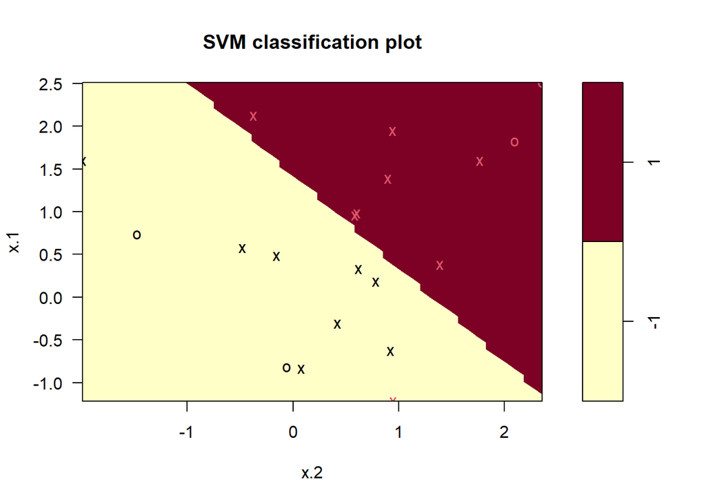

```r
svmfit <- svm(y ~ ., data = dat, kernel = "linear", cost = 0.1, scale = FALSE)
plot(svmfit, dat)
```

```r
svmfit$index
```

```
##  [1]  1  2  3  4  5  7  9 10 12 13 14 15 16 17 18 20
```

```r
set.seed(1)
tune.out <- tune(svm, y ~ ., data = dat, kernel = "linear",
                 ranges = list(cost = c(0.001, 0.01, 0.1, 1, 5, 10, 100)))
summary(tune.out)
```

```
##
## Parameter tuning of 'svm':
##
## - sampling method: 10-fold cross validation
##
## - best parameters:
##  cost
##   0.1
##
## - best performance: 0.05
##
## - Detailed performance results:
##    cost error dispersion
## 1 1e-03  0.55  0.4377975
## 2 1e-02  0.55  0.4377975
## 3 1e-01  0.05  0.1581139
## 4 1e+00  0.15  0.2415229
## 5 5e+00  0.15  0.2415229
## 6 1e+01  0.15  0.2415229
## 7 1e+02  0.15  0.2415229
```

```r
bestmod <- tune.out$best.model
summary(bestmod)
```

```
##
## Call:
## best.tune(METHOD = svm, train.x = y ~ ., data = dat, ranges = list(cost = c(0.001,
##     0.01, 0.1, 1, 5, 10, 100)), kernel = "linear")
##
##
## Parameters:
##    SVM-Type:  C-classification
##  SVM-Kernel:  linear
##        cost:  0.1
##
## Number of Support Vectors:  16
##
##  ( 8 8 )
##
##
## Number of Classes:  2
##
## Levels:
##  -1 1
```

```r
xtest <- matrix(rnorm(20 * 2), ncol = 2)
ytest <- sample(c(-1, 1), 20, rep = TRUE)
xtest[ytest == 1, ] <- xtest[ytest == 1, ] + 1
testdat <- data.frame(x = xtest, y = as.factor(ytest))
ypred <- predict(bestmod, testdat)
table(predict = ypred, truth = testdat$y)
```

```
##        truth
## predict -1 1
##      -1  9 1
##      1   2 8
```

```r
svmfit <- svm(y ~ ., data = dat, kernel = "linear", cost = 0.01, scale = FALSE)
ypred <- predict(svmfit, testdat)
table(predict = ypred, truth = testdat$y)
```

```
##        truth
## predict -1  1
##      -1 11  6
##      1   0  3
```

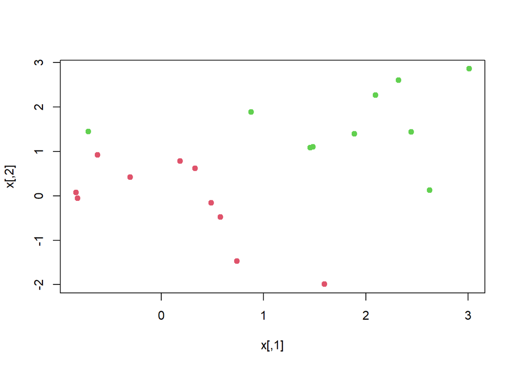

```r
x[y == 1, ] <- x[y == 1, ] + 0.5
plot(x, col = (y + 5) / 2, pch = 19)
```

```r
dat <- data.frame(x = x, y = as.factor(y))
svmfit <- svm(y ~ ., data = dat, kernel = "linear", cost = 1e5)
summary(svmfit)
```

```
##
## Call:
## svm(formula = y ~ ., data = dat, kernel = "linear", cost = 1e+05)
##
##
## Parameters:
##    SVM-Type:  C-classification
##  SVM-Kernel:  linear
##        cost:  1e+05
##
## Number of Support Vectors:  3
##
##  ( 1 2 )
##
##
## Number of Classes:  2
##
## Levels:
##  -1 1
```

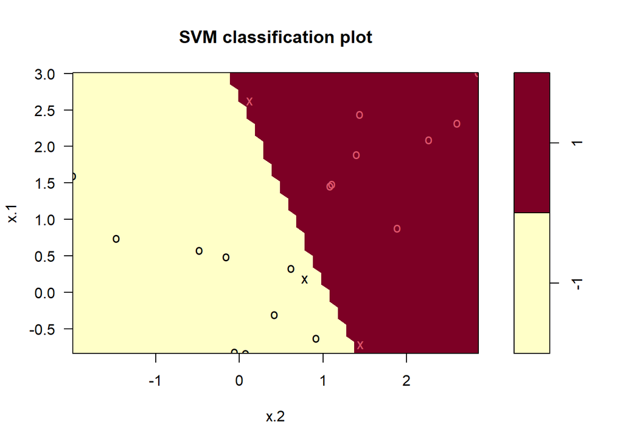

```r
plot(svmfit, dat)
```

```r
svmfit <- svm(y ~., data = dat, kernel = "linear", cost = 1)
summary(svmfit)
```

```
##
## Call:
## svm(formula = y ~ ., data = dat, kernel = "linear", cost = 1)
##
##
## Parameters:
##    SVM-Type:  C-classification
##  SVM-Kernel:  linear
##        cost:  1
##
## Number of Support Vectors:  7
##
##  ( 4 3 )
##
##
## Number of Classes:  2
##
## Levels:
##  -1 1
```

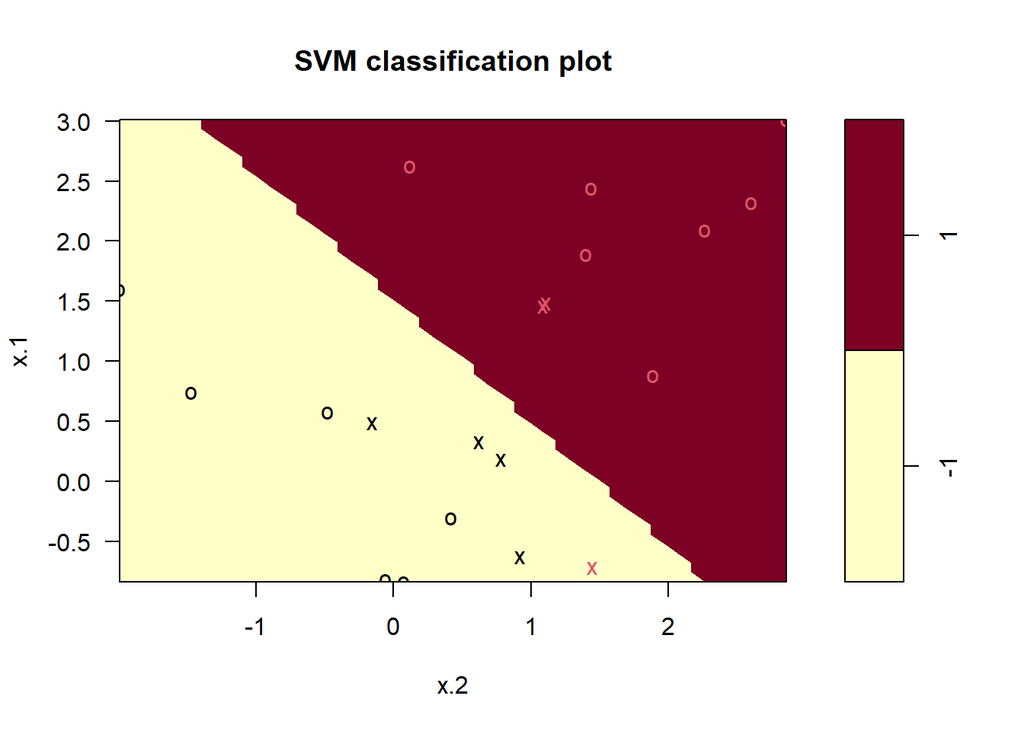

```r
plot(svmfit, dat)
```

# 9.6.2

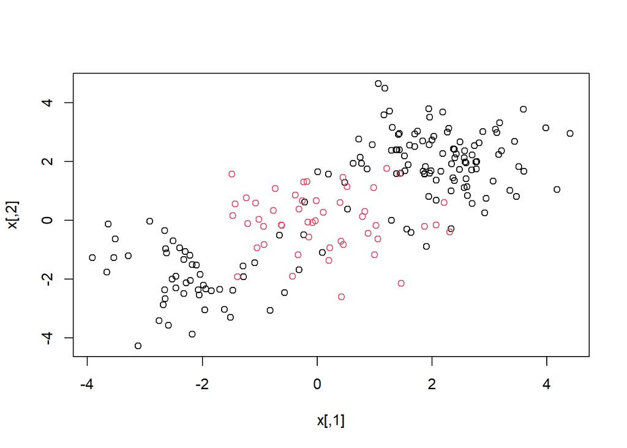

```r
set.seed(1)
x <- matrix(rnorm(200 * 2), ncol = 2)
x[1:100, ] <- x[1:100, ] + 2
x[101:150, ] <- x[101:150, ] - 2
y <- c(rep(1, 150), rep(2, 50))
dat <- data.frame(x =x, y = as.factor(y))
plot(x, col = y)
```

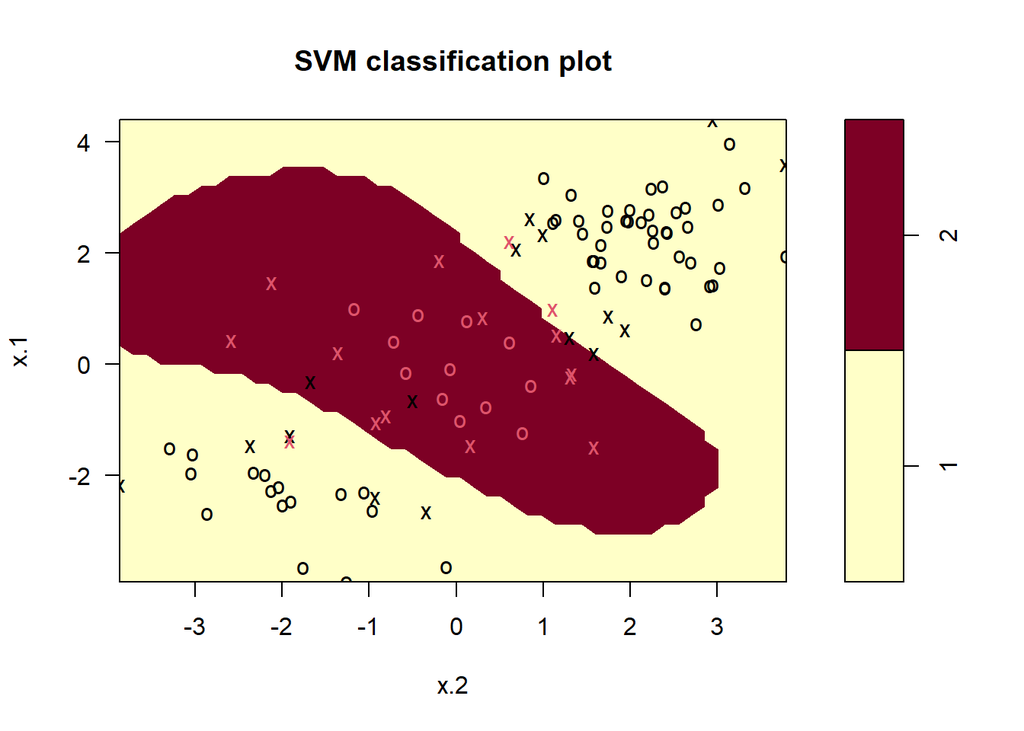

```r
train <- sample(200, 100)
svmfit <- svm(y ~ ., data = dat[train, ], kernel = "radial", gamma = 1, cost = 1)
plot(svmfit, dat[train, ])
```

```r
summary(svmfit)
```

```
##
## Call:
## svm(formula = y ~ ., data = dat[train, ], kernel = "radial", gamma = 1,
##     cost = 1)
##
##
## Parameters:
##    SVM-Type:  C-classification
##  SVM-Kernel:  radial
##        cost:  1
##
## Number of Support Vectors:  31
##
##  ( 16 15 )
##
##
## Number of Classes:  2
##
## Levels:
##  1 2
```

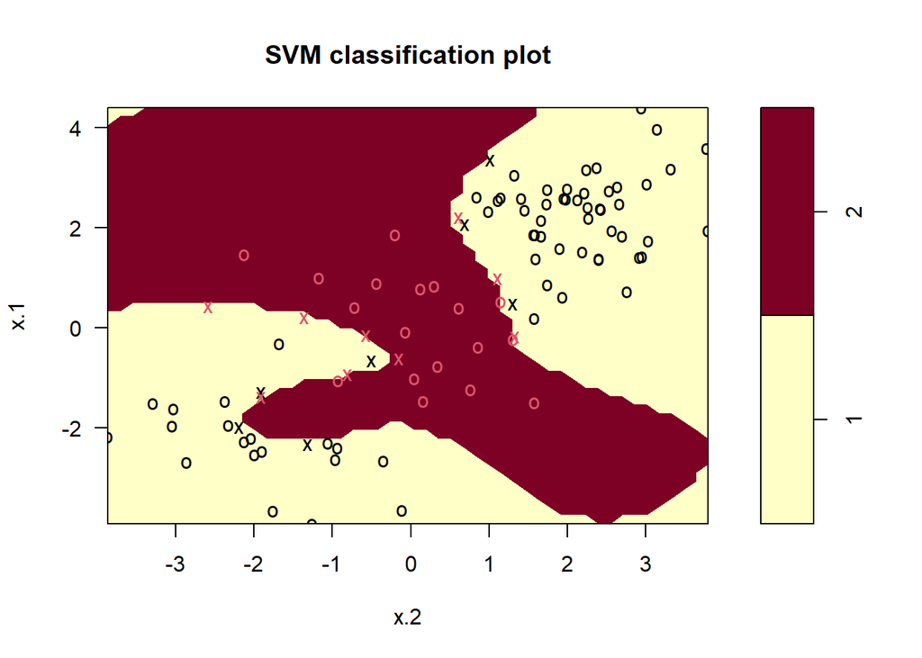

```r
svmfit <- svm(y ~ ., data = dat[train, ], kernel = "radial", gamma = 1, cost = 1e5)
plot(svmfit, dat[train, ])
```

```r
set.seed(1)
tune.out <- tune(svm, y ~ ., data = dat[train, ],
                 kernel = "radial",
                 ranges = list(
                   cost = c(0.1, 1, 10, 100, 1000),
                   gamma = c(0.5, 1, 2, 3, 4)
))
summary(tune.out)
```

```
##
## Parameter tuning of 'svm':
##
## - sampling method: 10-fold cross validation
##
## - best parameters:
##  cost gamma
##     1   0.5
##
## - best performance: 0.07
##
## - Detailed performance results:
##     cost gamma error dispersion
## 1  1e-01   0.5  0.26 0.15776213
## 2  1e+00   0.5  0.07 0.08232726
## 3  1e+01   0.5  0.07 0.08232726
## 4  1e+02   0.5  0.14 0.15055453
## 5  1e+03   0.5  0.11 0.07378648
## 6  1e-01   1.0  0.22 0.16193277
## 7  1e+00   1.0  0.07 0.08232726
## 8  1e+01   1.0  0.09 0.07378648
## 9  1e+02   1.0  0.12 0.12292726
## 10 1e+03   1.0  0.11 0.11005049
## 11 1e-01   2.0  0.27 0.15670212
## 12 1e+00   2.0  0.07 0.08232726
## 13 1e+01   2.0  0.11 0.07378648
## 14 1e+02   2.0  0.12 0.13165612
## 15 1e+03   2.0  0.16 0.13498971
## 16 1e-01   3.0  0.27 0.15670212
## 17 1e+00   3.0  0.07 0.08232726
## 18 1e+01   3.0  0.08 0.07888106
## 19 1e+02   3.0  0.13 0.14181365
## 20 1e+03   3.0  0.15 0.13540064
## 21 1e-01   4.0  0.27 0.15670212
## 22 1e+00   4.0  0.07 0.08232726
## 23 1e+01   4.0  0.09 0.07378648
## 24 1e+02   4.0  0.13 0.14181365
## 25 1e+03   4.0  0.15 0.13540064
```

```r
table(
  true = dat[-train, "y"],
  pred = predict(
    tune.out$best.model, newdata = dat[-train, ]
  )
)
```

```
##     pred
## true  1  2
##    1 67 10
##    2  2 21
```

# 9.6.3

```r
library(ROCR)
```

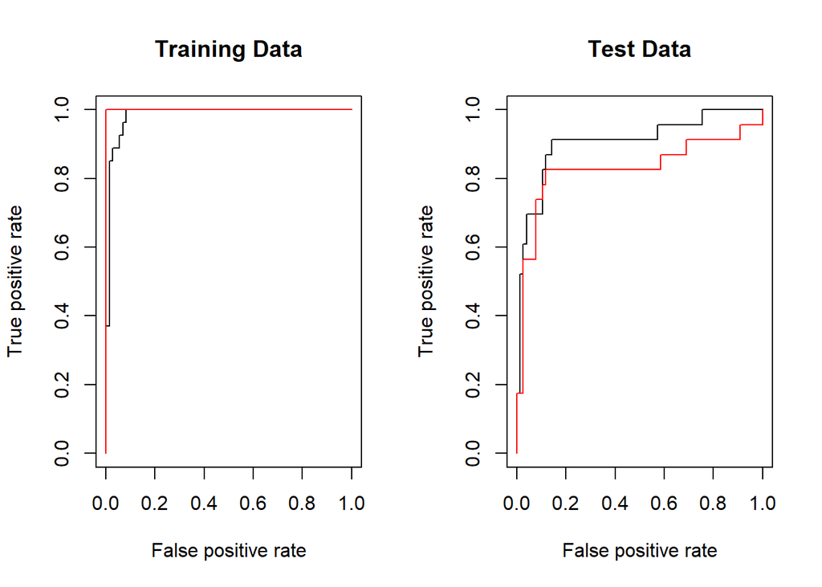

```r
rocplot <- function(pred, truth, ...) {
  predob <- prediction(pred, truth)
  perf <- performance(predob, "tpr", "fpr")
  plot(perf, ...)
}
svmfit.opt <- svm(y ~ ., data = dat[train, ],
                  kernel = "radial", gamma = 2, cost = 1,
                  decision.values = T)
fitted <- attributes(
  predict(svmfit.opt, dat[train, ], decision.values = TRUE)
)$decision.values
par(mfrow = c(1, 2))
rocplot(-fitted, dat[train, "y"], main = "Training Data")
svmfit.flex <- svm(y ~ ., data = dat[train, ],
                   kernel = "radial", gamma = 50, cost = 1,
                   decision.values = T)
fitted <- attributes(
  predict(svmfit.flex, dat[train, ], decision.values = T)
)$decision.values
rocplot(-fitted, dat[train, "y"], add = T, col = "red")
fitted <- attributes(
  predict(svmfit.opt, dat[-train, ], decision.values = T)
)$decision.values
rocplot(-fitted, dat[-train, "y"], main = "Test Data")
fitted <- attributes(
  predict(svmfit.flex, dat[-train, ], decision.values = T)
)$decision.values
rocplot(-fitted, dat[-train, "y"], add = T, col = "red")
```

# 9.7 Exercise

## Q5

# 5a

```r
x1=runif(500)-0.5
x2=runif(500)-0.5
y=1*(x1^2-x2^2 > 0 )
```

# 5b

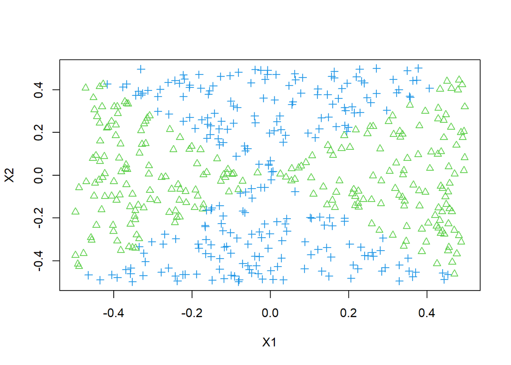

```r
plot(x1, x2, xlab = "X1", ylab = "X2", col = (4 - y), pch = (3 - y))
```

# 5c

```r
df <- data.frame(x1, x2, y = factor(y))
library(glmnet)
glm.fit <-  glm(y~ x1 + x2,family='binomial', data=data.frame(x1,x2,y))
glm.fit
```

```
##
## Call:  glm(formula = y ~ x1 + x2, family = "binomial", data = data.frame(x1,
##     x2, y))
##
## Coefficients:
## (Intercept)           x1           x2
##    -0.02445      0.28240     -0.05858
##
## Degrees of Freedom: 499 Total (i.e. Null);  497 Residual
## Null Deviance:       693.1
## Residual Deviance: 692.2     AIC: 698.2
```

```r
df$pred <- ifelse(predict(glm.fit, type = "response") > 0.5, 1, 0)
summary(glm.fit)
```

```
##
## Call:
## glm(formula = y ~ x1 + x2, family = "binomial", data = data.frame(x1,
##     x2, y))
##
## Coefficients:
##             Estimate Std. Error z value Pr(>|z|)
## (Intercept) -0.02445    0.08955  -0.273    0.785
## x1           0.28240    0.31280   0.903    0.367
## x2          -0.05858    0.30638  -0.191    0.848
##
## (Dispersion parameter for binomial family taken to be 1)
##
##     Null deviance: 693.08  on 499  degrees of freedom
## Residual deviance: 692.23  on 497  degrees of freedom
## AIC: 698.23
##
## Number of Fisher Scoring iterations: 3
```

# 5d

```r
table(df$pred)
```

```
##
##   0   1
## 304 196
```

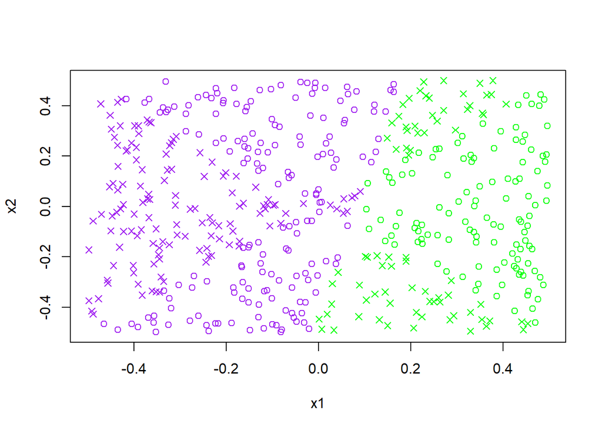

```r
glm.pred <- predict(glm.fit,data.frame(x1,x2))
plot(x1,x2,col = ifelse(glm.pred>0,'green','purple'),pch=ifelse(as.integer(glm.pred>0) == y,1,4))
```

```r
sum(df$y == df$pred) / nrow(df)
```

```
## [1] 0.586
```

# 5e

```r
glm.fit <- glm(y~ x1 + x2 + I(x1^2) + I(x2^2), family = "binomial", data=data.frame(x1,x2,y))
df$pred <- ifelse(predict(glm.fit, type = "response") > 0.5, 1, 0)
summary(glm.fit)
```

```
##
## Call:
## glm(formula = y ~ x1 + x2 + I(x1^2) + I(x2^2), family = "binomial",
##     data = data.frame(x1, x2, y))
##
## Coefficients:
##              Estimate Std. Error z value Pr(>|z|)
## (Intercept)     -7.17     318.46  -0.023    0.982
## x1              10.43    2103.98   0.005    0.996
## x2              14.95    4007.11   0.004    0.997
## I(x1^2)      32456.24  620581.15   0.052    0.958
## I(x2^2)     -32561.93  623099.59  -0.052    0.958
##
## (Dispersion parameter for binomial family taken to be 1)
##
##     Null deviance: 6.9308e+02  on 499  degrees of freedom
## Residual deviance: 1.0921e-05  on 495  degrees of freedom
## AIC: 10
##
## Number of Fisher Scoring iterations: 25
```

# 5f

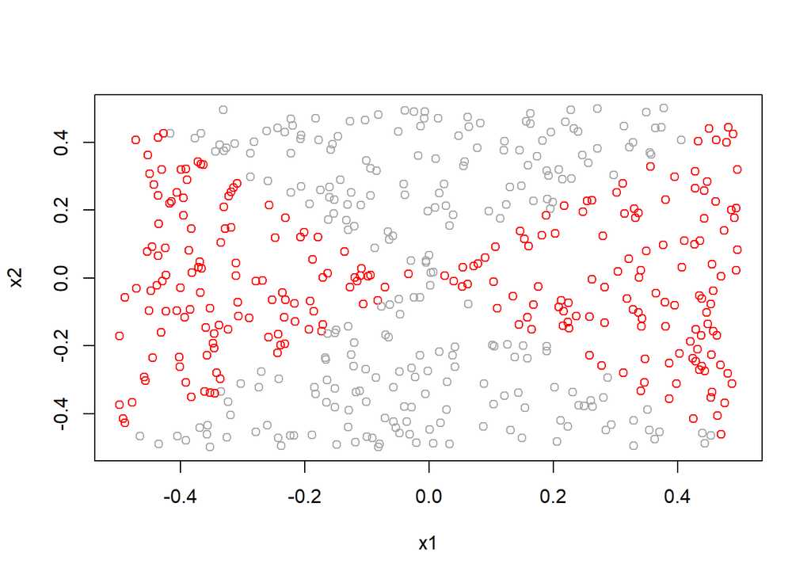

```r
glm.pred=predict(glm.fit,data.frame(x1,x2))
plot(x1,x2,col=ifelse(glm.pred>0,'red','darkgrey'),pch=ifelse(as.integer(glm.pred>0) == y,1,4))
```

# 5g

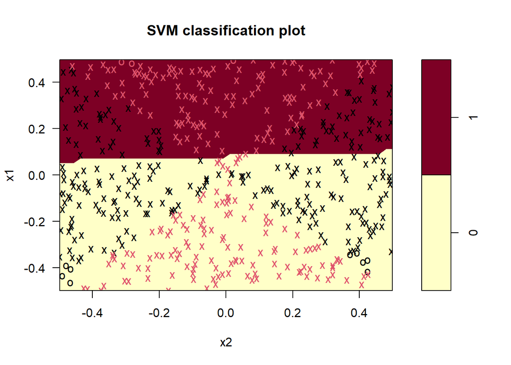

```r
library(e1071)
dat <- data.frame(x1 = x1, x2 = x2, y = as.factor(y))
svmfit <- svm(y ~ ., data = dat, kernel = "linear", cost = 10, scale = FALSE)
plot(svmfit, dat)
```

# 5h

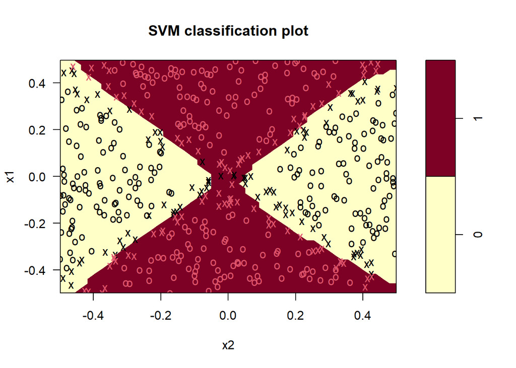

```r
set.seed(1)
dat <- data.frame(x1 = x1, x2 = x2, y = as.factor(y))
svmfit <- svm(y ~ x1 + x2, data = dat, kernel = "radial", gamma = 1, cost = 1)
plot(svmfit, dat)
```

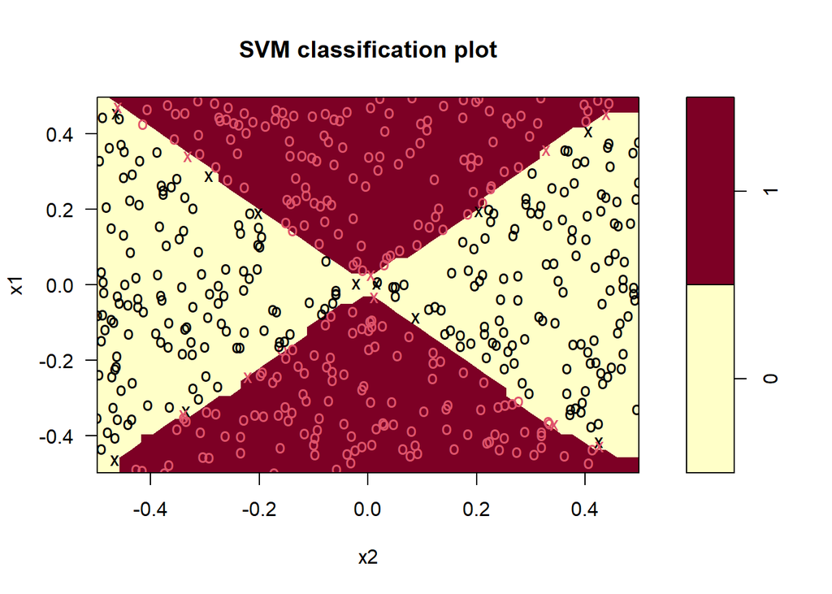

```r
svmfit <- svm(y ~ x1 + x2, data = dat, kernel = "radial", gamma = 1, cost = 1e5)
plot(svmfit, dat)
```

# 5i

#The graphs highlight the effectiveness of support vector machines (SVMs) with non-linear kernels in delineating non-linear boundaries

#Logistic regression with non-interactions and SVMs with linear kernels fail to find a clear decision boundary

#Introducing interaction terms to logistic regression appears to empower it similarly to radial-basis kernels

#Though, selecting the appropriate interaction terms involves manual effort and tuning, and this becomes challenging with a substantial number of features

#Radial basis kernels necessitate tuning only parameters gamma and cost facilitating an easier tuning process through cross-validation

## Q8

# 8a

```r
library(ISLR)
library(e1071)
set.seed(42)
train=sample(1:1070,800)
test=(1:1070)[-train]
n_train <- 800
n_test = length(test)
```

# 8b

```r
svm.fit=svm(Purchase~.,data=OJ,subset=train,cost=0.01,kernel='linear', scale = TRUE)
summary(svm.fit)
```

```
##
## Call:
## svm(formula = Purchase ~ ., data = OJ, cost = 0.01, kernel = "linear",
##     subset = train, scale = TRUE)
##
##
## Parameters:
##    SVM-Type:  C-classification
##  SVM-Kernel:  linear
##        cost:  0.01
##
## Number of Support Vectors:  432
##
##  ( 215 217 )
##
##
## Number of Classes:  2
##
## Levels:
##  CH MM
```

# 8c

```r
svm.pred <- predict(svm.fit, newdata = OJ[train, ])
table(predicted = svm.pred, truth = OJ[train, ]$Purchase)
```

```
##          truth
## predicted  CH  MM
##        CH 432  77
##        MM  60 231
```

```r
mean(OJ$Purchase[train] != svm.pred)
```

```
## [1] 0.17125
```

```r
svm.pred <- predict(svm.fit, newdata = OJ[test, ])
table(predicted = svm.pred, truth = OJ[test, ]$Purchase)
```

```
##          truth
## predicted  CH  MM
##        CH 142  25
##        MM  19  84
```

```r
mean(OJ$Purchase[test] != svm.pred)
```

```
## [1] 0.162963
```

# 8d

```r
svm.tune=tune(svm, Purchase~.,data=OJ[train,], ranges=data.frame(cost=seq(0.01,10,25)), kernel='linear')
summary(svm.tune)
```

```
##
## Error estimation of 'svm' using 10-fold cross validation: 0.1825
```

```r
svm.tune=tune(svm, Purchase~.,data=OJ[test,], ranges=data.frame(cost=seq(0.01,10,25)), kernel='linear')
summary(svm.tune)
```

```
##
## Error estimation of 'svm' using 10-fold cross validation: 0.1925926
```

# 8e

```r
svm.pred=predict(svm.tune$best.model,OJ[train, ])
table(predicted = svm.pred, truth = OJ[train, ]$Purchase)
```

```
##          truth
## predicted  CH  MM
##        CH 434  78
##        MM  58 230
```

```r
train.error = 1 - sum(svm.pred == OJ[train, ]$Purchase)/n_train
train.error
```

```
## [1] 0.17
```

```r
svm.pred=predict(svm.tune$best.model,OJ[test, ])
table(predicted = svm.pred, truth = OJ[test, ]$Purchase)
```

```
##          truth
## predicted  CH  MM
##        CH 140  26
##        MM  21  83
```

```r
test.error = 1 - sum(svm.pred == OJ[test, ]$Purchase)/n_test
test.error
```

```
## [1] 0.1740741
```

# 8f

```r
svm.fit=svm(Purchase~.,data=OJ,subset=train,cost=0.01,kernel='radial')
summary(svm.fit)
```

```
##
## Call:
## svm(formula = Purchase ~ ., data = OJ, cost = 0.01, kernel = "radial",
##     subset = train)
##
##
## Parameters:
##    SVM-Type:  C-classification
##  SVM-Kernel:  radial
##        cost:  0.01
##
## Number of Support Vectors:  621
##
##  ( 308 313 )
##
##
## Number of Classes:  2
##
## Levels:
##  CH MM
```

```r
svm.pred=predict(svm.fit,OJ[train,])
table(OJ[train,'Purchase'],svm.pred)
```

```
##     svm.pred
##       CH  MM
##   CH 492   0
##   MM 308   0
```

```r
mean(OJ$Purchase[train] != svm.pred)
```

```
## [1] 0.385
```

```r
svm.pred=predict(svm.fit,OJ[test,])
table(OJ[test,'Purchase'],svm.pred)
```

```
##     svm.pred
##       CH  MM
##   CH 161   0
##   MM 109   0
```

```r
mean(OJ$Purchase[test] != svm.pred)
```

```
## [1] 0.4037037
```

```r
svm.tune=tune(svm, Purchase~.,data=OJ[train,], ranges=data.frame(cost=seq(0.01,10,25)), kernel='radial')
summary(svm.tune)
```

```
##
## Error estimation of 'svm' using 10-fold cross validation: 0.385
```

```r
svm.tune=tune(svm, Purchase~.,data=OJ[test,], ranges=data.frame(cost=seq(0.01,10,25)), kernel='radial')
summary(svm.tune)
```

```
##
## Error estimation of 'svm' using 10-fold cross validation: 0.4037037
```

```r
svm.pred=predict(svm.tune$best.model,OJ[train,])
table(OJ[train,'Purchase'],svm.pred)
```

```
##     svm.pred
##       CH  MM
##   CH 492   0
##   MM 308   0
```

```r
mean(OJ$Purchase[train] != svm.pred)
```

```
## [1] 0.385
```

```r
svm.pred=predict(svm.tune$best.model,OJ[test,])
table(OJ[test,'Purchase'],svm.pred)
```

```
##     svm.pred
##       CH  MM
##   CH 161   0
##   MM 109   0
```

```r
mean(OJ$Purchase[test] != svm.pred)
```

```
## [1] 0.4037037
```